# Tipología y Ciclo de Vida de los Datos: Práctica 2 - Limpieza y análisis de datos

## 3.3 Comprobación de la normalidad y homogeneidad de la varianza.

Para este caso en particular, las variables numericas que existian se transofrmaton en categóricas por lo que las pruebas de normalidad y homogeneidad carecen de sentido.

## 3.4 Aplicación de pruebas estadísticas para comparar los grupos de datos. En función de los datos y el objetivo del estudio, aplicar pruebas de contraste de hipótesis, correlaciones, regresiones, etc. Aplicar al menos tres métodos de análisis diferentes.

```r
cat <- c("workclass","education","marital_status","occupation" ,"race","sex","native_country","target","age_r","capital_net_r","hour_per_week_r")

# Posibles combinaciones de variables categóricas
combinaciones     <- as.data.frame(t(combn(cat, 2)))

# Prueba Chi-Square pata categóricas
chisq_prueba <-
  apply(t(combinaciones), 2, function(x){
                           c(Var1   = x[1],
                             Var2   = x[2],
                             pvalue = chisq.test(adult[, x[1]],
                                                 adult[, x[2]])$p.value)
  })

chisq_prueba <- chisq_prueba %>%
  t() %>%
  data.frame(stringsAsFactors=FALSE)

chisq_prueba$pvalue <- as.numeric(chisq_prueba$pvalue)

chisq_prueba<- chisq_prueba%>%
  arrange(pvalue)

knitr::kable(chisq_prueba, caption = "Tabla de correlaciones --categóricas-- ",
             format = "markdown", padding = 0,
             col.names = c("", "", "p-value"))
```

|  |  | p-value |
| --- | --- | --- |
| workclass | education | 0.0000000 |
| workclass | occupation | 0.0000000 |
| workclass | age_r | 0.0000000 |
| workclass | hour_per_week_r | 0.0000000 |
| education | occupation | 0.0000000 |
| education | target | 0.0000000 |
| education | age_r | 0.0000000 |
| education | capital_net_r | 0.0000000 |
| education | hour_per_week_r | 0.0000000 |
| marital_status | sex | 0.0000000 |
| marital_status | target | 0.0000000 |
| marital_status | age_r | 0.0000000 |
| marital_status | hour_per_week_r | 0.0000000 |
| occupation | target | 0.0000000 |
| occupation | age_r | 0.0000000 |
| occupation | hour_per_week_r | 0.0000000 |
| race | native_country | 0.0000000 |
| sex | target | 0.0000000 |
| sex | hour_per_week_r | 0.0000000 |
| target | age_r | 0.0000000 |
| target | capital_net_r | 0.0000000 |
| target | hour_per_week_r | 0.0000000 |
| age_r | hour_per_week_r | 0.0000000 |
| workclass | marital_status | 0.0000000 |
| education | native_country | 0.0000000 |
| workclass | sex | 0.0000000 |
| workclass | target | 0.0000000 |
| marital_status | capital_net_r | 0.0000000 |
| occupation | capital_net_r | 0.0000000 |
| age_r | capital_net_r | 0.0000000 |
| marital_status | occupation | 0.0000000 |
| marital_status | race | 0.0000000 |
| education | marital_status | 0.0000000 |
| race | sex | 0.0000000 |
| capital_net_r | hour_per_week_r | 0.0000000 |
| sex | age_r | 0.0000000 |
| workclass | race | 0.0000000 |
| occupation | sex | 0.0000000 |
| race | target | 0.0000000 |
| race | hour_per_week_r | 0.0000000 |
| education | race | 0.0000000 |
| workclass | capital_net_r | 0.0000000 |
| sex | capital_net_r | 0.0000000 |
| occupation | race | 0.0000000 |
| education | sex | 0.0000000 |
| workclass | native_country | 0.0000000 |
| race | age_r | 0.0000000 |
| marital_status | native_country | 0.0000000 |
| race | capital_net_r | 0.0000000 |
| native_country | target | 0.0000000 |
| native_country | hour_per_week_r | 0.0000000 |
| native_country | age_r | 0.0000051 |
| occupation | native_country | 0.0001612 |
| native_country | capital_net_r | 0.0002307 |
| sex | native_country | 0.0141993 |

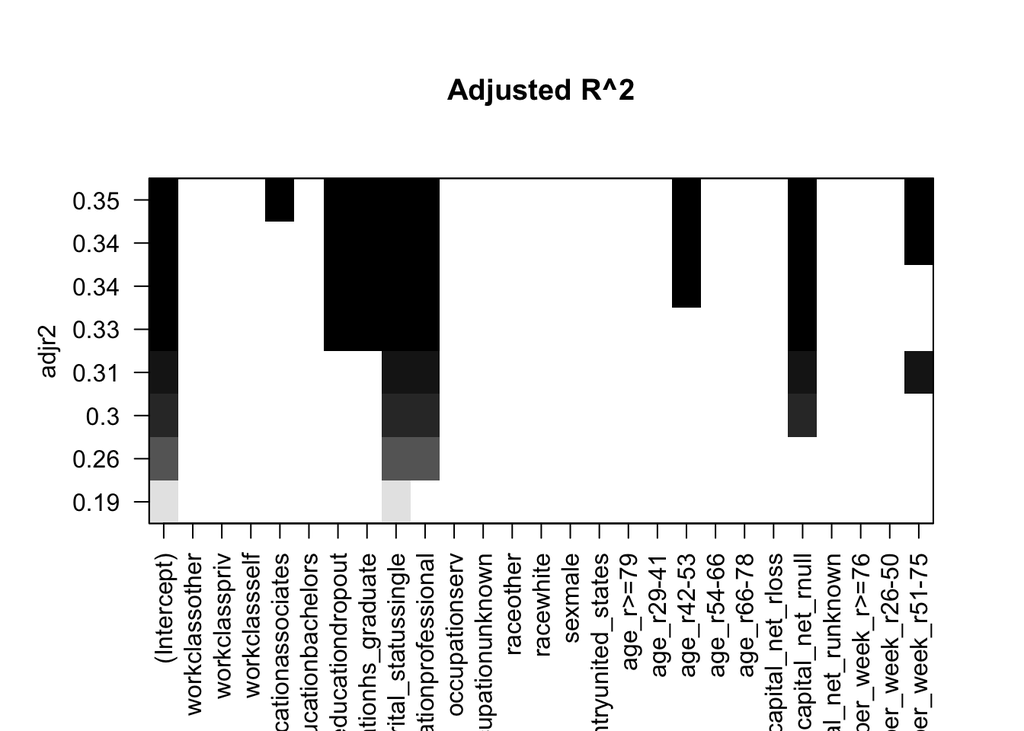

```r
# modelo de búsqueda
adult[cat] = as.data.frame(apply(adult[cat],2,
                                         function(x) as.factor(x)))

search_output<-regsubsets(target~workclass+education+marital_status+occupation+race+sex+native_country+age_r+capital_net_r+hour_per_week_r,
                          data=adult, method="exhaustive")
plot(search_output, scale = "adjr2", main = "Adjusted R^2")
```

```r
cols_1 <- c("education","marital_status","age_r","hour_per_week_r",
            "capital_net_r","target")
cols_2 <- c("education","marital_status","age_r","hour_per_week_r",
            "capital_net_r")
```

Con el objetivo de tener los datos finales solicitados, se exporta este conjunto de datos.

```r
# Export data a csv
write.csv(adult, "adult_data.csv")
```

Se utilizan los datos finales para elaborar un árbol de decisión que nos ayude en el predicción del ingreso.

```r
# train data set
train <- adult[adult["df"]=="train",cols_1]
trainX <- train[cols_2]
trainy <- train$target

# test data set
test <- adult[adult["df"]=="test",cols_1]
testX <- test[cols_2]
testy <- test$target

#C5.o model
model <- C50::C5.0(trainX, trainy,rules=TRUE )
summary(model)
```

```
##
## Call:
## C5.0.default(x = trainX, y = trainy, rules = TRUE)
##
##
## C5.0 [Release 2.07 GPL Edition]      Tue Jan  7 00:58:15 2020
## -------------------------------
##
## Class specified by attribute `outcome'
##
## Read 32561 cases (6 attributes) from undefined.data
##
## Rules:
##
## Rule 1: (8972/383, lift 1.3)
##  education in {associates, dropout, hs_graduate}
##  age_r in {<29, >=79, 66-78}
##  ->  class <=50k  [0.957]
##
## Rule 2: (9982/485, lift 1.3)
##  age_r in {<29, >=79, 66-78}
##  capital_net_r = null
##  ->  class <=50k  [0.951]
##
## Rule 3: (3633/181, lift 1.3)
##  hour_per_week_r = <25
##  capital_net_r = null
##  ->  class <=50k  [0.950]
##
## Rule 4: (4253/244, lift 1.2)
##  education = dropout
##  ->  class <=50k  [0.942]
##
## Rule 5: (17144/1105, lift 1.2)
##  marital_status = single
##  ->  class <=50k  [0.935]
##
## Rule 6: (21999/2859, lift 1.1)
##  education in {associates, dropout, hs_graduate}
##  capital_net_r = null
```

[output cut: 49 more lines]

```
##    ----  ----
##   23222  1498    (a): class <=50k
##    3867  3974    (b): class >50k
##
##
##  Attribute usage:
##
##   83.90% education
##   82.56% capital_net_r
##   68.86% marital_status
##   49.31% age_r
##   22.98% hour_per_week_r
##
##
## Time: 0.1 secs
```

```r
model_t <- C50::C5.0(trainX, trainy)
summary(model_t)
```

```
##
## Call:
## C5.0.default(x = trainX, y = trainy)
##
##
## C5.0 [Release 2.07 GPL Edition]      Tue Jan  7 00:58:17 2020
## -------------------------------
##
## Class specified by attribute `outcome'
##
## Read 32561 cases (6 attributes) from undefined.data
##
## Decision tree:
##
## marital_status = marrried:
## :...education in {advanced,bachelors}:
## :   :...capital_net_r in {gain,loss,unknown}: >50k (1239/116)
## :   :   capital_net_r = null:
## :   :   :...hour_per_week_r = <25: <=50k (223/80)
## :   :       hour_per_week_r in {>=76,26-50,51-75}:
## :   :       :...age_r in {<29,>=79,66-78}: <=50k (348/162)
## :   :           age_r in {29-41,42-53,54-66}: >50k (2758/883)
## :   education in {associates,dropout,hs_graduate}:
## :   :...capital_net_r = null: <=50k (9274/2580)
## :       capital_net_r = unknown: >50k (32)
## :       capital_net_r in {gain,loss}:
## :       :...education = dropout: <=50k (192/58)
## :           education in {associates,hs_graduate}:
## :           :...age_r in {<29,>=79,66-78}: <=50k (206/79)
## :               age_r in {29-41,42-53,54-66}: >50k (1145/398)
## marital_status = single:
## :...capital_net_r = null: <=50k (15727/694)
##     capital_net_r in {gain,loss,unknown}:
##     :...education in {dropout,hs_graduate}: <=50k (808/124)
##         education in {advanced,associates,bachelors}:
##         :...capital_net_r = loss: <=50k (209/60)
##             capital_net_r = unknown: >50k (16)
##             capital_net_r = gain:
##             :...age_r in {<29,>=79,66-78}: <=50k (107/35)
##                 age_r in {29-41,42-53,54-66}: >50k (277/101)
```

[output cut: 12 more lines]

```
##    ----  ----
##   23222  1498    (a): class <=50k
##    3872  3969    (b): class >50k
##
##
##  Attribute usage:
##
##  100.00% marital_status
##  100.00% capital_net_r
##   51.70% education
##   14.87% age_r
##   10.22% hour_per_week_r
##
##
## Time: 0.0 secs
```

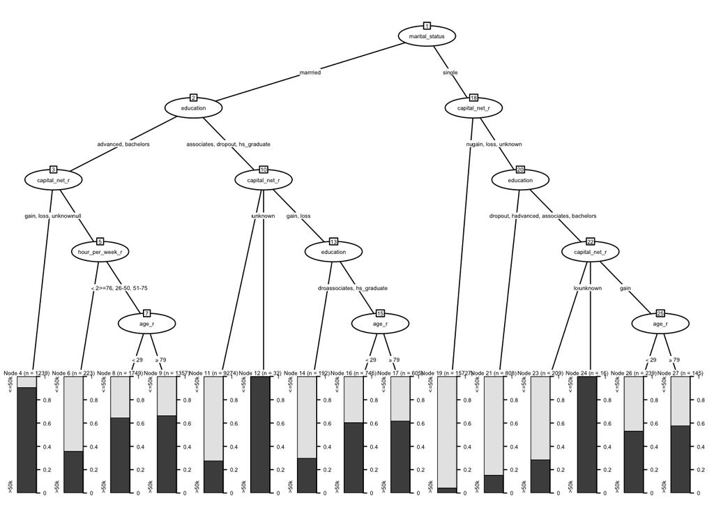

```r
plot(model_t, gp = gpar(fontsize = 4))
```

```r
model_t_pred<-predict(model_t,newdata =testX,type="class")
confusionMatrix(model_t_pred,testy)
```

```
## Confusion Matrix and Statistics
##
##           Reference
## Prediction <=50k  >50k
##      <=50k 11714  1902
##      >50k    721  1944
##
##                Accuracy : 0.8389
##                  95% CI : (0.8332, 0.8445)
##     No Information Rate : 0.7638
##     P-Value [Acc > NIR] : < 2.2e-16
##
##                   Kappa : 0.5006
##
##  Mcnemar's Test P-Value : < 2.2e-16
##
##             Sensitivity : 0.9420
##             Specificity : 0.5055
##          Pos Pred Value : 0.8603
##          Neg Pred Value : 0.7295
##              Prevalence : 0.7638
##          Detection Rate : 0.7195
##    Detection Prevalence : 0.8363
##       Balanced Accuracy : 0.7237
##
##        'Positive' Class : <=50k
##
```

# 4 Representación de los resultados a partir de tablas y gráficas.

Transformación y limpieza variables categóricas.

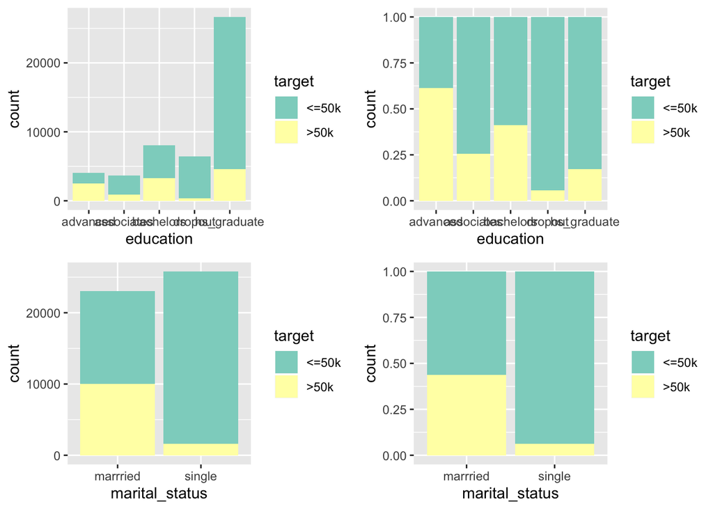

```r
# Distribución final en relación a variable target
p1 = ggplot(data=adult,aes(x=education,fill=target)) + geom_bar() +
  scale_fill_brewer(palette="Set3")
p2 = ggplot(data = adult,aes(x=education,fill=target)) + geom_bar(position="fill") +
  scale_fill_brewer(palette="Set3")
p3 = ggplot(data=adult,aes(x=marital_status,fill=target)) + geom_bar() +
  scale_fill_brewer(palette="Set3")
p4 = ggplot(data = adult,aes(x=marital_status,fill=target)) +
  geom_bar(position="fill") +
  scale_fill_brewer(palette="Set3")
grid.arrange(p1,p2,p3,p4, ncol =2)
```

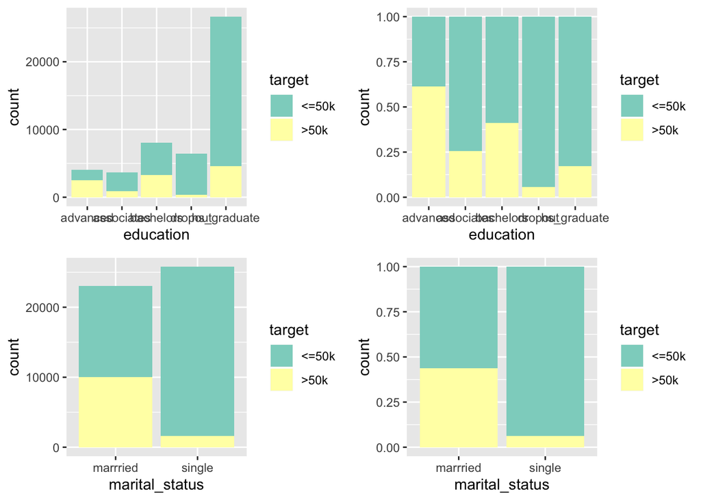

```r
p5 = ggplot(data=adult,aes(x=age_r,fill=target)) + geom_bar() +
  scale_fill_brewer(palette="Set3")
p6 = ggplot(data = adult,aes(x=age_r,fill=target)) + geom_bar(position="fill") +
  scale_fill_brewer(palette="Set3")
p7 = ggplot(data=adult,aes(x=hour_per_week_r,fill=target)) + geom_bar() +
  scale_fill_brewer(palette="Set3")
p8 = ggplot(data = adult,aes(x=hour_per_week_r,fill=target)) +
  geom_bar(position="fill") +
  scale_fill_brewer(palette="Set3")
grid.arrange(p1,p2,p3,p4, ncol =2)
```

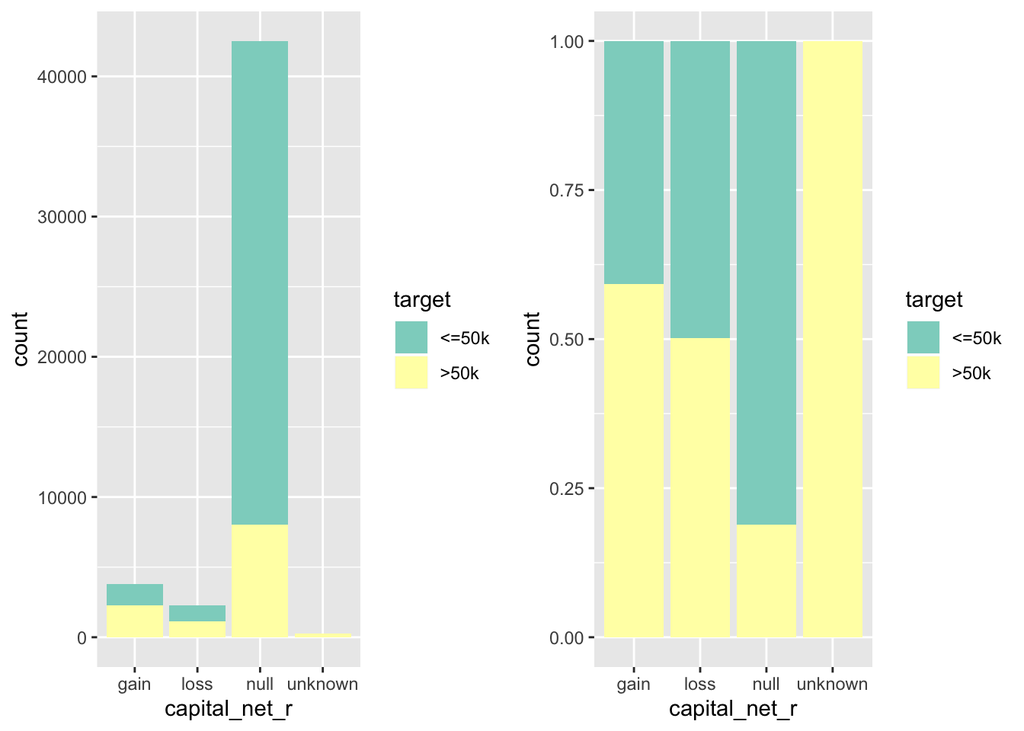

```r
p9 = ggplot(data=adult,aes(x=capital_net_r,fill=target)) + geom_bar() +
  scale_fill_brewer(palette="Set3")
p10 = ggplot(data = adult,aes(x=capital_net_r,fill=target)) +
  geom_bar(position="fill") +
  scale_fill_brewer(palette="Set3")
grid.arrange(p9,p10, ncol =2)
```

# 5 Resolución del problema. A partir de los resultados obtenidos, ¿cuáles son las conclusiones? ¿Los resultados permiten responder al problema?

# 6 Código: Hay que adjuntar el código, preferiblemente en R, con el que se ha realizado la limpieza, análisis y representación de los datos. Si lo preferís, también podéis trabajar en Python.

El código se encuentra integrado en el informe.

*Este trabajo se realizó de manera individual, por esta razón se omite la tabla solicitada ETNG*